# R Notebook

# Reduccion de Datos

Reducir la base de datos , pero manteniendo la informacion,

Porque quieres reducir? porque entre tantas variables es dificil encontrar patrones

Las mas conocidas - Agregacion del cubo de datos - Discretizacion *** (solo se toca este tema) - Reduccion de dimensionalidad ( se ve en multivariados)

¿Que es Discretizacion ? Transforma una var. cualitativa (ordinal) en cuantitativa Las variables categoricas tienes distribucion discretas

Motivos: -Cuando quiero usar la variable categorica para realizar clasificar. - quiero usar un modelo con variables discretas, por ejemplo el algoritmo Naive Bayes, en arboles de regresion ( si ingresas una variable cualitativa, lo discretiza) - Cuando mi finalidad es realizar predicciones

Algoritmo de discretizacion :

- 1ro : Ordenar los datos de mayor a menor
- 2do : Se definen intervalos
- 3ro : Se asignan valores a los intervalos

| X \| $Xô$ \| |
| --- |
| 15 \| 1 \| |
| 20 \| 1 \| |
| 24 \| 1 \| |
| 32 \| 2 \| |
| 50 \| 2 \| |
| 80 \| 3 \| |
| 89 \| 3 \| |
| 90 \| 4 \| |
| 97 \| 4 \| |

Las discretizacion puede ser de top-down o bottom-up

Metodo top - down :

Metodo bottom - up :

Cada dato esta en un intervalo

Discretizacion dinamica : Cuando es realizada por un algoritmo de un software

Discretizacion estatica : Cuando al discretizacion no se usa un mecanismo u algoritmo

## Discretizacion

Metodos No Supervisados : Solo tengo en cuenta los datos , por ejemplo los auartiles

Metodos Supervisados : Cuando se tiene una clase que se usa para realizar un mecanismo de clasificacion.

```
     "class" =  clase
        |     D3
```

| X \| $Xô$ \| Y \| X |
| --- |
| 15 \| 1 \| No \| 1 |
| 20 \| 1 \| Si \| 1 |
| 24 \| 1 \| No \| 1 |

32 | 2 | No | 2 50 | 2 | No | 2 —————– 80 | 3 | Si | 3 89 | 3 | Si | 3 —————– 90 | 4 | Si | 3 97 | 4 | Si | 3

# ————————————————————————

# Ejemplo: Cr?ditos de Banco Alem?n

#————————————————————————-#

```r
library(Fahrmeir)
data(credit)
help(credit)

head(credit)
```

|  | Y | Cuenta | Mes | Ppag | Uso | DM | Sexo | Estc |
| --- | --- | --- | --- | --- | --- | --- | --- | --- |
| 1 | buen | no | 18 | pre buen pagador | privado | 1049 | mujer | vive solo |
| 2 | buen | no | 9 | pre buen pagador | profesional | 2799 | hombre | no vive solo |
| 3 | buen | bad running | 12 | pre buen pagador | profesional | 841 | mujer | vive solo |
| 4 | buen | no | 12 | pre buen pagador | profesional | 2122 | hombre | no vive solo |
| 5 | buen | no | 12 | pre buen pagador | profesional | 2171 | hombre | no vive solo |
| 6 | buen | no | 10 | pre buen pagador | profesional | 2241 | hombre | no vive solo |

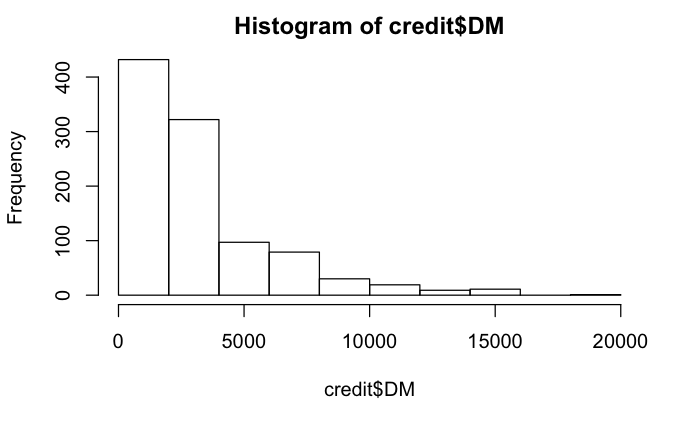

```r
hist(credit$DM)
```

```r
install.packages("arules")
```

# Discretizacion con intervalos de igual amplitud

Forma de determinar la amplitud de un intervalo:

- Determinar la amplitud de cada intervalo en forma arbitraria ( regla de negocio)
- Usar una regla estadistica : - Formula de Sturges : no tiene en cuenta la diversidad de los datos, solo la cantidad de datos - Formula de Friedman - Diaconis : - Formula de Scott :

Usa la desviacion estandar

```r
library(arules)
nbins<-nclass.scott(credit$DM) # Usando Scott
nbins
```

```
[1] 19
```

```r
nbins<-nclass.Sturges(credit$DM) #Usando Sturges
nbins
```

```
[1] 11
```

Usa un rango intercuartilico

```r
nbins<-nclass.FD(credit$DM) # Usando Friedman-Diaconis
nbins
```

```
[1] 35
```

Nos quedamos con Scott ( n = 19)

```r
credit$DM_dia<-discretize(credit$DM,method="interval", breaks= nbins)
table(credit$DM_dia)
```

```
     [250,1.21e+03) [1.21e+03,2.16e+03) [2.16e+03,3.12e+03) [3.12e+03,4.08e+03) [4.08e+03,5.03e+03)
                169                 298                 175                 117                  54
[5.03e+03,5.99e+03) [5.99e+03,6.95e+03)  [6.95e+03,7.9e+03)  [7.9e+03,8.86e+03) [8.86e+03,9.82e+03)
                 37                  42                  36                  17                  13
[9.82e+03,1.08e+04) [1.08e+04,1.17e+04) [1.17e+04,1.27e+04) [1.27e+04,1.36e+04) [1.36e+04,1.46e+04)
                 10                   7                  10                   2                   6
[1.46e+04,1.56e+04) [1.56e+04,1.65e+04) [1.65e+04,1.75e+04) [1.75e+04,1.84e+04]
                  2                   4                   0                   1
```

[output not shown]

# Discretizacion por clusters (K-Medias)

```r
#Discretizaci?n por clusters (K-Medias)
credit$DM_cl<-discretize(credit$DM, method = "cluster", breaks = 5)  #  5 centros de intervalos
table(credit$DM_cl)
```

```
     [250,2.19e+03)  [2.19e+03,4.2e+03)  [4.2e+03,6.73e+03) [6.73e+03,1.06e+04) [1.06e+04,1.84e+04]
                472                 294                 117                  83                  34
```

# DISCRETIZACION POR ENTROPIA

```
     "class" =  clase
        |     D3
```

| X \| $Xô$ \| Y \| X |
| --- |
| 15 \| 1 \| No \| 1 |
| 20 \| 1 \| Si \| 1 |
| 24 \| 1 \| No \| 1 |

32 | 2 | No | 2 50 | 2 | No | 2 —————– 80 | 3 | Si | 3 89 | 3 | Si | 3 —————– 90 | 4 | Si | 3 97 | 4 | Si | 3

La probabilidad de los 3 ultimos intervalos es mejor que el 1er intervalo

En los intervalos cuando la probabilidad es 50 % es malo

Eventos mutuamente excluyentes : son eventos que no pueden suceder al mismo tiempo.

La entropia , mide la impureza que tengo para medir la clasificacion de ciertas informacion

entropia 1 : máxima informacion posible ( el conjunto esta muy mezclado) entropia 0 : mínima informacion posible ( el conjunto de datos es puro)

[output not shown]

## 1er paso :

- Entropia de Y sin discretizar de X . Todos los datos de X estan en un solo intervalo

$$E(S) = - [ \frac{4}{9}*log2(\frac{4}{9}) + \frac{5}{9}*log2(\frac{5}{9})]$$

```r
EntropiaInicial = - (4/9*log2(4/9) + 5/9*log2(5/9))
EntropiaInicial
```

```
[1] 0.9910761
```

## 2do paso :

- Divido X en 2 intervalos . Se identifica los puntos de cortes

Se escoge T4 = 17 como punto de corte

Calcular cuanto vale la entropia para el primer intervalo S1

3 veces “yes” 2 veces “no”

$$E(S1) = - [ \frac{3}{5}*log2(\frac{3}{5}) + \frac{2}{5}*log2(\frac{2}{5})]$$

```r
entropia_S1 = - (3/5*log2(3/5) + 2/5*log2(2/5))
entropia_S1
```

```
[1] 0.9709506
```

Calcular cuanto vale la entropia para el primer intervalo S2

1 veces “yes” 3 veces “no”

$$E(S2) = - [ \frac{1}{4}*log2(\frac{1}{4}) + \frac{3}{4}*log2(\frac{3}{4})]$$

```r
entropia_S2 = - (1/4*log2(1/4) + 3/4*log2(3/4))
entropia_S2
```

```
[1] 0.8112781
```

La entropia de todo el sistema ( S1 + S2) seria la media ponderada

```r
EntropiaFinalConIntervalos  = (5* entropia_S1 + 4*entropia_S2) /( 5 + 4)
EntropiaFinalConIntervalos
```

```
[1] 0.8999851
```

La Ganancia final es la reduccion de la entropia

$$Gain(S, T4) = Entropia Inicial - Entropia Final con Intervalos$$

```r
Gain_S_T4 = EntropiaInicial - EntropiaFinalConIntervalos
Gain_S_T4
```

```
[1] 0.09109101
```

NOTA : En caso se desea usar mas de 2 intervalos, se podria usar la pruebas de Homogenidad de proporciones : Realizar la comparacion entre varios intervalos

# Discretizacion

```r
install.packages("discretization")
```

```r
#Discretizacion por entropia
library(discretization)

# primero pasar las columnas que quieras discretizar, seguido de las  clases
DM_entropia = mdlp(data = credit[,c("DM","Y")])
```

```r
str(DM_entropia)
```

```
List of 2
 $ cutp     :List of 1
  ..$ : num 3910
 $ Disc.data:'data.frame':  1000 obs. of  2 variables:
  ..$ DM: int [1:1000] 1 1 1 1 1 1 1 1 1 1 ...
  ..$ Y : Factor w/ 2 levels "buen","mal": 1 1 1 1 1 1 1 1 1 1 ...
```

$cutp : punto de corte, los valores que determinar los puntos de corte del intervalo $Disc.data : base de datos discretizadas

```r
DM_entropia$cutp  # se obtiene el punto de corte
```

```
[[1]]
[1] 3909.5
```

Se obtiene un punto de corte , por lo tanto se tiene 2 intervalos

|  | DM | Y |
| --- | --- | --- |
| 1 | 1 | buen |
| 2 | 1 | buen |
| 3 | 1 | buen |
| 4 | 1 | buen |
| 5 | 1 | buen |
| 6 | 1 | buen |
| 7 | 1 | buen |
| 8 | 1 | buen |
| 9 | 1 | buen |
| 10 | 1 | buen |

[output cut: 990 more lines]

```r
DM_entropia$cutp
```

```
[[1]]
[1] 3909.5
```

|  | DM | Y |
| --- | --- | --- |
| 1 | 1 | buen |
| 2 | 1 | buen |
| 3 | 1 | buen |
| 4 | 1 | buen |
| 5 | 1 | buen |
| 6 | 1 | buen |
| 7 | 1 | buen |
| 8 | 1 | buen |
| 9 | 1 | buen |
| 10 | 1 | buen |

[output cut: 5 more lines]

```r
table(DM_entropia$Disc.data)
```

```
   Y
DM  buen mal
  1  550 189
  2  150 111
```

|  | Y | Cuenta | Mes | Ppag | Uso | DM | Sexo | Estc | DM_dia | DM_dif | DM_cl | DM_dentr |
| --- | --- | --- | --- | --- | --- | --- | --- | --- | --- | --- | --- | --- |
| 1 | buen | no | 18 | pre buen pagador | privado | 1049 | mujer | vive solo | [250,1.21e+03) | [935,1.26e+03) | [250,2.19e+03) | 1 |
| 2 | buen | no | 9 | pre buen pagador | profesional | 2799 | hombre | no vive solo | [2.16e+03,3.12e+03) | [2.32e+03,2.85e+03) | [2.19e+03,4.2e+03) | 1 |
| 3 | buen | bad running | 12 | pre buen pagador | profesional | 841 | mujer | vive solo | [250,1.21e+03) | [250,935) | [250,2.19e+03) | 1 |
| 4 | buen | no | 12 | pre buen pagador | profesional | 2122 | hombre | no vive solo | [1.21e+03,2.16e+03) | [1.91e+03,2.32e+03) | [250,2.19e+03) | 1 |
| 5 | buen | no | 12 | pre buen pagador | profesional | 2171 | hombre | no vive solo | [2.16e+03,3.12e+03) | [1.91e+03,2.32e+03) | [250,2.19e+03) | 1 |
| 6 | buen | no | 10 | pre buen pagador | profesional | 2241 | hombre | no vive solo | [2.16e+03,3.12e+03) | [1.91e+03,2.32e+03) | [2.19e+03,4.2e+03) | 1 |

```r
table(credit$DM_dentr)
```

```
  1   2
739 261
```